# Data visualization with ggplot2

POLI 210 - Seminar 9

Brad LeVeck

October 28, 2026

## Questions for this seminar

- How persistent is a district’s Democratic vote?
- How do House and presidential voting line up?
- What does the distribution of congressional ideology look like within parties?
- How can we display the summaries and fitted results in a published paper?

Reading: PSD Chapter 7. Today we build a few useful plots, one layer at a time.

## What does one row mean?

| Data | One row | Important limitation |
| --- | --- | --- |
| `elections` | Retained district-election | Selected extract, not all races |
| `matched` | Retained district-election with a unique member match | Following Congress; not voter ideology |
| `house` | Member record, 114th House | May include replacements |

The election file has 9,337 rows, 1946–2014. Its 2014 subset has 328 rows. Do not turn these counts into national seat totals.

## A small grammar of graphics

```r
ggplot(data = e2014, mapping = aes(x = dvp, y = dv)) +
  geom_point() +
  labs(x = "Prior Democratic House vote (%)",
       y = "Democratic House vote, 2014 (%)")
```

- **Data:** which rows and columns?
- **Mapping:** which variables control positions, colors, or other features?
- **Geometry:** points, bars, lines, boxes …
- **Labels/scales/theme:** explain and refine the display.

## Each point is a district-election

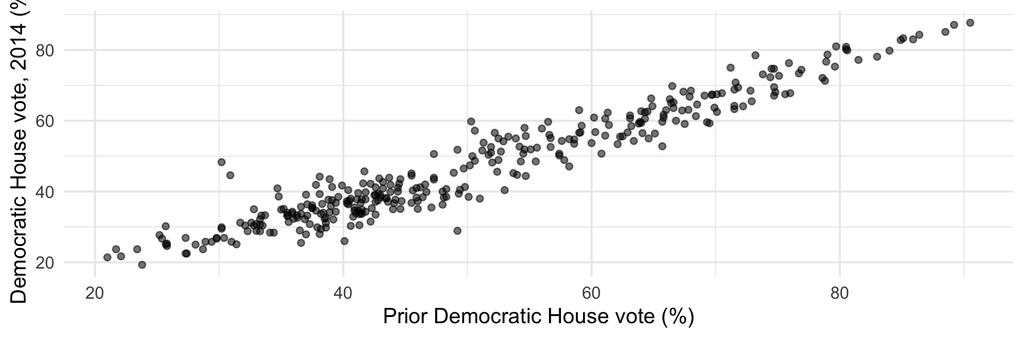

`dvp`: prior House election. `dv`: current House election. Both are percentages.

## Add a variable through a mapping

```r
ggplot(e2014, aes(dvp, dv)) +
  geom_point(aes(color = incumbent), alpha = 0.7) +
  scale_color_manual(values = inc_colors)
```

`aes(color = incumbent)` says: look up each row’s incumbent category and map it to color.

`alpha = 0.7` says: make **every** point partly transparent.

## Incumbency provides additional context

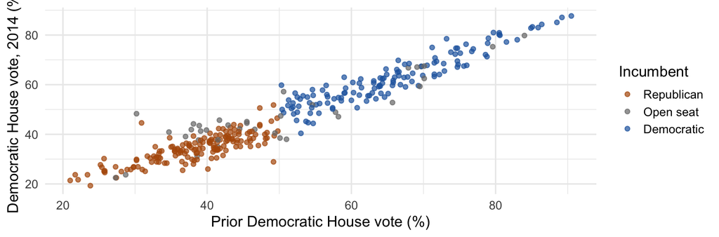

This is a descriptive pattern, not an estimate of the causal effect of incumbency.

## Mapping versus setting

```r
geom_point(aes(color = incumbent)) # Variable -> colors + legend
geom_point(color = "blue")        # One fixed color
geom_point(aes(color = "blue"))   # A category called "blue"!
```

Inside `aes()`: map a variable (or expression) to a visual feature. Outside `aes()`: set a constant appearance.

`color` controls points/lines/outlines; `fill` controls interiors of bars and ribbons.

## Layers inherit mappings

```r
ggplot(e2014, aes(dvp, dv)) +
  geom_point(aes(color = incumbent), alpha = 0.7) +
  geom_smooth(method = "lm", formula = y ~ x,
              se = FALSE, color = "black")
```

Color is mapped **only in the point layer**. The fitted line uses all rows. Putting a categorical color mapping in `ggplot()` would normally fit a line for each group.

We specify a straight-line fit explicitly. Regression interpretation comes later.

## One fitted line, several point colors

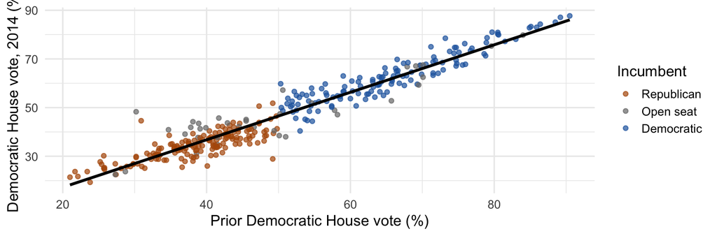

The line summarizes the relationship; it does not establish causation.

## Facets repeat a plot for subsets

```r
ggplot(recent, aes(dvp, dv)) +
  geom_point(alpha = 0.4) +
  geom_abline(slope = 1, intercept = 0, linetype = 2) +
  facet_wrap(~year, nrow = 2)
```

The dashed line marks unchanged Democratic vote share, not a fitted relationship. Fixed axes make panels comparable. These are the five latest years in our extract.

## Comparing elections on the same axes

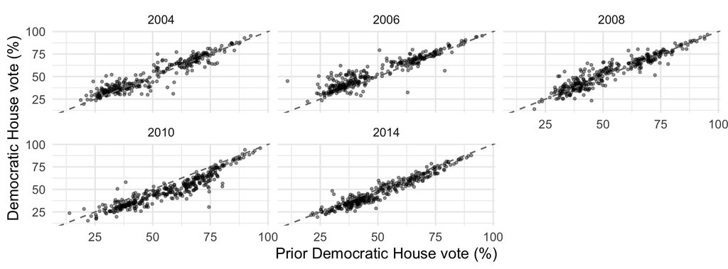

In which panels do observations tend to fall below the equality line?

## House vote and presidential vote

`dpres` measures district Democratic two-party presidential vote (%). For a midterm House election, it refers to the preceding presidential election.

```r
pres <- elections |> filter(!is.na(dpres))
ggplot(pres, aes(dpres, dv)) +
  geom_point(alpha = 0.14, size = 0.7) +
  geom_smooth(method = "lm", formula = y ~ x, se = FALSE)
```

There are 8,212 usable rows. Transparency helps with overlapping points.

## Pooled elections: a strong descriptive pattern

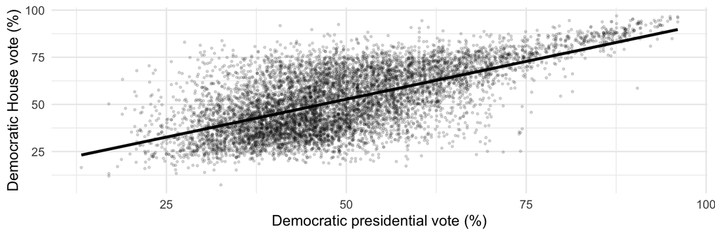

Pooling years can conceal change. A fitted line is not a substitute for checking subsets.

## Matching elections to member ideology

The prepared file matches an election to the **following Congress**: 2014 → 114th Congress (2015–2017), using state and district.

- The color plot includes only keys with exactly one House member record.
- Ambiguous or unmatched keys are retained in the data, not guessed.
- Of 8,212 rows with `dpres`, 8,061 have a usable unique match.

NOMINATE dimension 1 describes the member’s roll-call ideology. It is **not** a district opinion measure or a predictor known before that election.

## Continuous color: member ideology

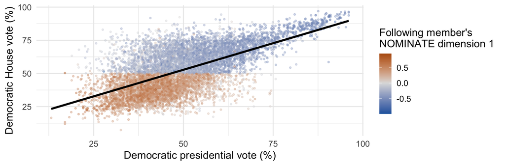

Blue = more liberal; orange = more conservative. The black fit ignores the color mapping.

## Presidential vote and member ideology in 2014

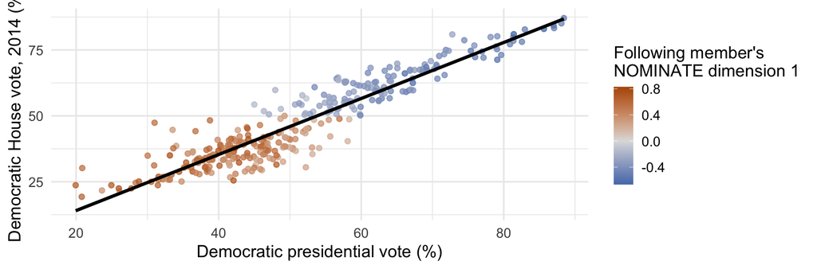

2014 only: easier to see the observations; still a selected, descriptive comparison.

## Interpreting the House-vote scatterplot

With prior House vote (`dvp`) on x and current House vote (`dv`) on y:

- **Equality line (`dv = dvp`):** points above it indicate an increase in Democratic vote share.
- **Incumbent colors:** distinguish districts with Republican incumbents, Democratic incumbents, and open seats.
- **Facets by election:** reveal whether patterns persist or change across years.

Why might a line fitted to all districts differ from separate lines fitted within incumbent categories?

## Break

Next: move from individual observations to distributions and summaries.

The key question remains: **What quantity does the height or position represent?**

## Count rows or plot an existing value?

| Goal | Geometry | Input |
| --- | --- | --- |
| Count cases in categories | `geom_bar()` | Individual rows |
| Count cases in numeric intervals | `geom_histogram()` | Individual rows |
| Show a calculated mean/proportion | `geom_col()` | Summary rows |

`geom_bar()` counts by default. `geom_col()` uses your y values. Using the wrong one changes the question the plot answers.

## Histograms: numeric intervals

```r
ggplot(e2014, aes(dpres)) +
  geom_histogram(binwidth = 5, boundary = 0,
                 fill = "steelblue", color = "white")
```

Bin width is **5 percentage points**. Each height counts retained districts in that interval.

Bin widths of 2, 5, and 10 show different levels of detail using the same observations. For a density-scaled histogram, map `y = after_stat(density)` instead.

## Distribution of presidential vote, 2014 districts

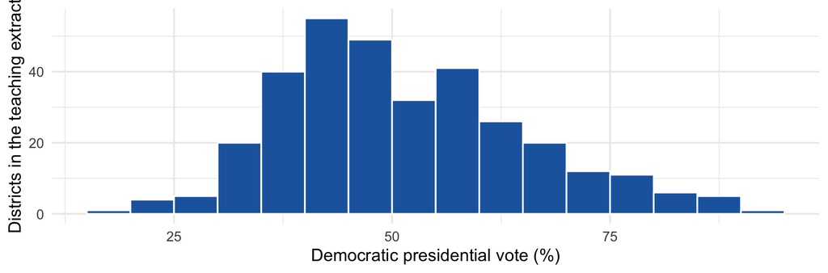

These are district counts, not counts of voters.

## Bars for counts of categories

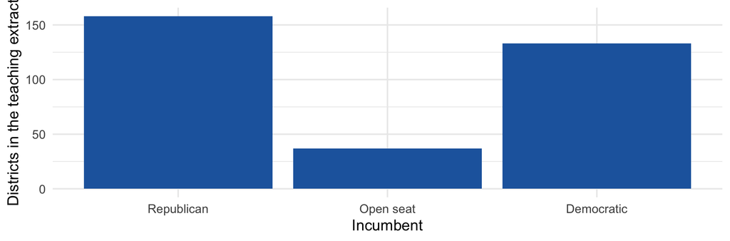

`ggplot(e2014, aes(incumbent)) + geom_bar()` counts the rows in each category.

## Bars for calculated means

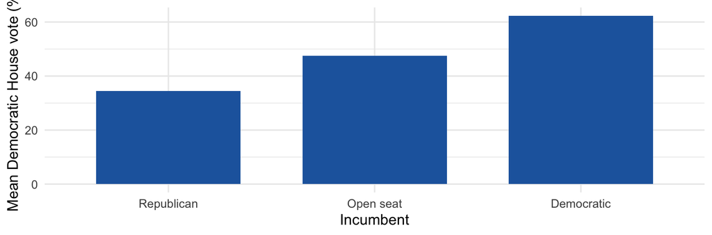

`ggplot(means, aes(incumbent, mean_dv)) + geom_col()` uses the summary table’s y column.

## Reshape first, then map

Our original data have separate columns `dv` and `dvp`. For grouped bars, one column should name the election; another should contain the vote.

```r
vote_long <- e2014 |>
  select(incumbent, dv, dvp) |>
  pivot_longer(c(dv, dvp),
               names_to = "election", values_to = "vote")
```

One row now represents a district’s vote at **one of two times**. This does not create additional independent districts.

## Calculate before drawing

```r
vote_summary <- vote_long |>
  group_by(incumbent, election) |>
  summarise(mean_vote = mean(vote), n = n(),
            se = sd(vote) / sqrt(n()), .groups = "drop")
```

One row now represents an incumbent category × election summary.

The `se` formula is an **illustrative IID calculation**. This selected election extract does not justify treating it as a representative random sample.

## The summary table behind the plot

| incumbent | election | mean_vote | n | se |
| --- | --- | --- | --- | --- |
| Republican | Prior | 38.51 | 158 | 0.52 |
| Republican | 2014 | 34.40 | 158 | 0.46 |
| Open seat | Prior | 49.90 | 37 | 2.40 |
| Open seat | 2014 | 47.56 | 37 | 2.16 |
| Democratic | Prior | 65.35 | 133 | 0.86 |
| Democratic | 2014 | 62.31 | 133 | 0.89 |

`sd(vote)` describes variation across districts. `sd(vote)/sqrt(n)` estimates the standard error of a mean under IID sampling. They answer different questions.

## Side by side, not stacked

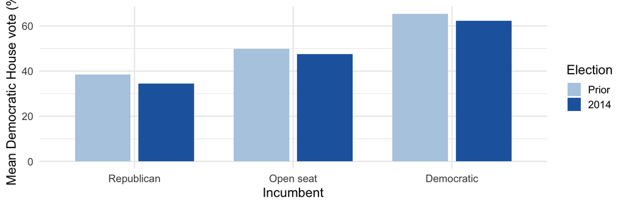

Map election to `fill`; use `position_dodge(width = 0.8)`. Keep bar baselines at zero.

## Add uncertainty to the same positions

```r
dodge <- position_dodge(width = 0.8)
ggplot(vote_summary, aes(incumbent, mean_vote, fill = election)) +
  geom_col(position = dodge) +
  geom_errorbar(aes(ymin = mean_vote - se,
                    ymax = mean_vote + se),
                position = dodge, width = 0.18)
```

Use the same dodge for bars and whiskers. Whisker width is a graphical choice; interval height comes from the calculated endpoints.

## Interpreting the whiskers

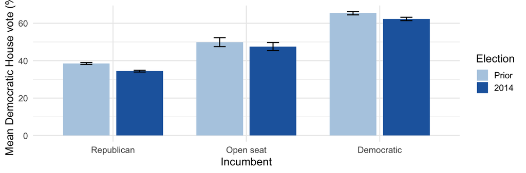

Here: mean ±1 illustrative IID SE. Not ±1 SD; not a 95% confidence interval. B4 supplies bootstrap endpoints for Figure 1 instead.

## A boxplot summarizes a distribution

- Center line: median.
- Box: 25th to 75th percentile (the interquartile range, IQR).
- Whiskers: most extreme observations within 1.5 IQR of the box edges.
- Points beyond the whiskers: observations, not automatically errors.

A box is **not a confidence interval for the mean**. Compare spread, asymmetry, and location, not just one number.

## Member ideology within parties

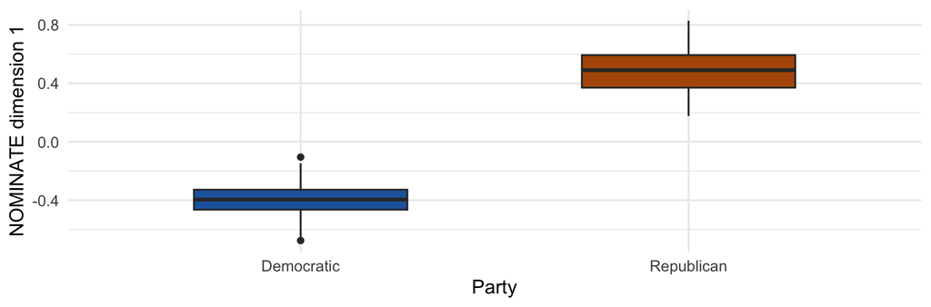

`geom_boxplot()` calculates the summaries from member-level rows. 114th House, Democratic and Republican member records with available scores.

## Lines and ribbons can use supplied results

Suppose `predictions` has `x`, `estimate`, `lower`, `upper`, and `series`.

```r
ggplot(predictions, aes(x, estimate)) +
  geom_ribbon(aes(ymin = lower, ymax = upper,
                  fill = series, group = series), alpha = 0.2) +
  geom_line(aes(color = series))
```

Draw the ribbon first so it does not cover the line. These rows are **predictions at a grid of x values**, not new observations.

## Different layers can use different tables

```r
ggplot() +
  geom_point(data = observed, aes(x, outcome), alpha = 0.5) +
  geom_line(data = predictions, aes(x, estimate))
```

Start with an empty `ggplot()` and supply each layer’s `data` and mappings. Otherwise a layer may inherit a column name that its own table does not have.

This is the pattern for B4’s observed experience points and supplied fitted curves.

## Finish and save a reproducible plot

```r
p <- ggplot(e2014, aes(dvp, dv)) +
  geom_point(alpha = 0.5) +
  labs(x = "Prior Democratic vote (%)", y = "2014 Democratic vote (%)") +
  theme_minimal(base_size = 13)
p
ggsave("house-vote.png", plot = p, width = 7, height = 4.5, dpi = 300)
```

In Quarto, printing `p` includes it in the report. `ggsave()` is for a separate file. Check labels and units at the size the reader will actually see.

## B4: seven panels, three kinds of input

| Figure | What you prepare or receive | Plot |
| --- | --- | --- |
| 1A–C | Group means/proportions + bootstrap endpoints | Bars + whiskers |
| 2A | Supplied patience predictions | Lines + 95% ribbons |
| 2B | Supplied differences relative to K=0 | Bars + SE whiskers |
| 3A–B | Elite observations + supplied log-experience fits | Points + lines + ribbons |

Download the archive files; do not join overlapping samples by row number. Each source table determines the quantity shown by a panel’s heights or positions.

## Optional: a Normal Q–Q plot

Compare the observed quantile at each probability with a Normal quantile at that probability.

If a distribution is approximately Normal, the points should follow roughly a straight line. The intercept and slope can reflect a nonzero mean and a nonunit SD.

The reference line passes through the first and third quartiles by default. Systematic curvature or tail departures are useful diagnostics, not a pass/fail test.

## Optional: compare within parties

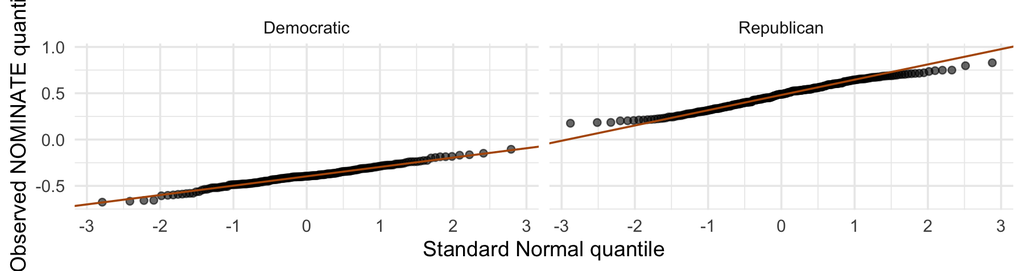

```r
ggplot(house, aes(sample = nominate_dim1)) +
  stat_qq() + stat_qq_line() + facet_wrap(~party)
```

## Optional: what a Q–Q plot does not establish

- NOMINATE scores need not be Normal for these descriptive plots to be useful.
- A mixture of parties can be non-Normal even when within-party shapes look simpler.
- A variable’s distribution is not the sampling distribution of its mean.

## Reading and sources

- [PSD Chapter 7: Data visualization](https://probstatsdata.com/ggplotviz.html).
- Jacobson (2015), [election replication archive](https://doi.org/10.7910/DVN/29559); selected teaching extract.
- [Voteview member data documentation](https://voteview.com/articles/data_help_members); frozen October 20, 2026 download.
- LeVeck et al. (2014), [The role of self-interest in elite bargaining](https://doi.org/10.1073/pnas.1409885111), *PNAS* 111(52): 18536–18541; [replication data](https://doi.org/10.7910/DVN/27894).
- [ggplot2 reference](https://ggplot2.tidyverse.org/reference/): geoms, mappings, scales, and facets.